# The Other Kind of Accessible

**Removing software barriers for disabled researchers and RSEs**

Eli Chadwick *(he/him and they/them)*

The Carpentries

5 September 2023

# Introduction

## About Me

- RSE for 5 years
- SSI Fellow since 2021
- Currently an IT Developer at The Carpentries
- Use voice control and eye tracking software due to chronic RSI
- Started studying disability and accessibility after discovering how much harder it was to use the web with assistive tech

## Motivation

- I straddle two worlds - RSE and web accessibility
- The word “accessible” is thrown around a lot in both
- But it means very different things
- Sometimes see ‘software ergonomics,’ ‘software usability,’ mentioned in RSE space
- These tread the same ground, but rarely mention disability
- I want to bring disability back into these conversations
- There is accessibility expertise in industry that we as RSEs can learn from

# What is the “Other Kind of Accessible”?

## “Accessible” in FAIR for research software <sup>1</sup>

**Software, and its metadata, is retrievable via standardised protocols**.

A1. Software is retrievable by its identifier using a standardised communications protocol.

A1.1. The protocol is open, free, and universally implementable.

A1.2. The protocol allows for an authentication and authorization procedure, where necessary.

A2. Metadata are accessible, even when the software is no longer available.

[^1]: [Introducing the FAIR Principles for research software](https://www.nature.com/articles/s41597-022-01710-x) by Michelle Barker, Neil P. Chue Hong, Daniel S. Katz, Anna-Lena Lamprecht, Carlos Martinez-Ortiz, Fotis Psomopoulos, Jennifer Harrow, Leyla Jael Castro, Morane Gruenpeter, Paula Andrea Martinez, and Tom Honeyman

## “Accessible” in a disability context

> Accessibility means that [disabled] people can do what they need to do in a **similar amount of time and effort** as someone that does not have a disability.  
> It means that people are empowered, can be independent, and will not be frustrated by something that is poorly designed or implemented. <sup>1</sup>

**The A in FAIR does not cover this!**

[^2]: [What we mean when we talk about accessibility](https://accessibility.blog.gov.uk/2016/05/16/what-we-mean-when-we-talk-about-accessibility-2/) by Alistair Duggin

## Digital Accessibility, a.k.a. “a11y”

a11y is a numeronym - like an acronym, but with numbers

Typically pronounced “ah-lee” or “A-eleven-Y”

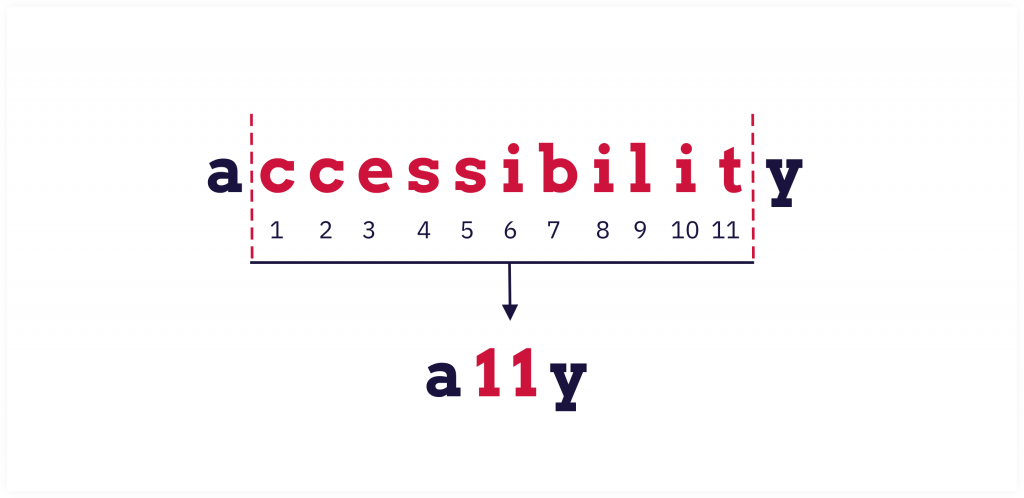

Image © [The A11y Collective](https://www.a11y-collective.com)

# Disability and Barriers

## Models of Disability: Medical model <sup>1</sup>

- Disability is the result of an impairment
- Treatment aims to ‘fix’ the disability or provide special individual services
- The disabled individual is expected to take the responsibility for adjusting
- “She can’t read the newspaper because she is blind”
[^3]: [Introduction to the Social and Medical Models of Disability](https://www.ombudsman.org.uk/sites/default/files/FDN-218144_Introduction_to_the_Social_and_Medical_Models_of_Disability.pdf)

## Models of Disability: Social model <sup>1</sup>

- Disability is the result of barriers in society; separate to impairment
- A person may be more disabled by some environments than others
- It is everyone’s responsibility to remove barriers that disable people
- “She can’t read the newspaper because it’s not published in large text or Braille”

**The social model is broadly preferred by the disabled community**

Ask yourself: what barriers exist within my software that I could remove?

[^4]: [Introduction to the Social and Medical Models of Disability](https://www.ombudsman.org.uk/sites/default/files/FDN-218144_Introduction_to_the_Social_and_Medical_Models_of_Disability.pdf)

## Barriers We Create

- Text formatting - colour, size, font
- Screen reader incompatibility
- Lack of captions/transcripts
- Small buttons and other controls
- Controls that don’t support both keyboard & mouse
- Complex page layout
- Complex text
- Animations, especially moving/flickering/blinking content
- Lack of instruction
- Lack of support
- Inaccessible events
- …

## Example study - Jupyter Notebooks

In a study of 100,000 randomly chosen Jupyter notebooks: <sup>1</sup>

- 48.36% start with a heading in the first cell
- 4.53% of notebooks included data tables after a chart
- 0.19% of notebook images had alt text - and most of those are just “image,” “png,” “alt,” etc.

The study also found systemic issues:

- matplotlib doesn’t support embedding alt text into image files
- Jupyter default themes for HTML exports don’t meet a11y guidelines
[^5]: [Notably Inaccessible – Data Driven Understanding of Data Science Notebook (In)Accessibility](https://arxiv.org/abs/2308.03241) by Venkatesh Potluri, Sudheesh Singanamalla, Nussara Tieanklin, and Jennifer Mankoff

# Why Should I Care?

## I don’t have disabled users!

- Are you sure?
- Are you sure that you will *never* have disabled users?
- Are disabled people who *want* to be your users turned away at the point of entry?
  - They will not tell you
  - They will just leave

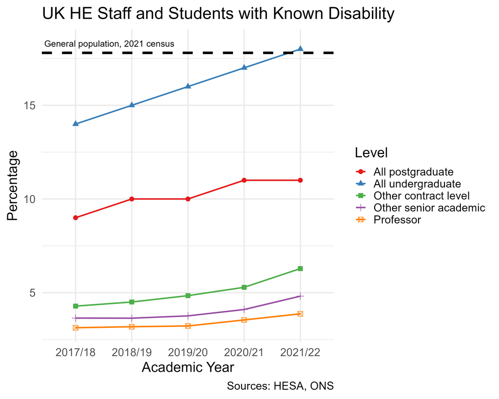

Percentage of students/staff with known disabilities. <sup>1</sup> <sup>2</sup>

| level | 2017/18 | 2018/19 | 2019/20 | 2020/21 | 2021/22 |
| --- | --- | --- | --- | --- | --- |
| All postgraduate | 9.0 | 10.0 | 10.0 | 11.0 | 11.0 |
| All undergraduate | 14.0 | 15.0 | 16.0 | 17.0 | 18.0 |
| Other contract level | 4.3 | 4.5 | 4.8 | 5.3 | 6.3 |
| Other senior academic | 3.6 | 3.6 | 3.8 | 4.1 | 4.8 |
| Professor | 3.1 | 3.2 | 3.2 | 3.5 | 3.9 |

General population: 17.8% <sup>3</sup>

[^6]: [Higher Education Staff Statistics: UK, 2021/22](https://www.hesa.ac.uk/news/17-01-2023/sb264-higher-education-staff-statistics%20https://www.hesa.ac.uk/data-and-analysis/students/whos-in-he)
[^7]: [Higher Education Student Statistics: UK, 2021/22](https://www.hesa.ac.uk/news/19-01-2023/sb265-higher-education-student-statistics)
[^8]: [Disability, England and Wales - 2021 Census](https://www.ons.gov.uk/peoplepopulationandcommunity/healthandsocialcare/healthandwellbeing/bulletins/disabilityenglandandwales/census2021#disability-england-and-wales)

## It’s the law

UK Equality Act 2010

- “…where a provision, criterion or practice of A’s puts a disabled person at a substantial disadvantage… take such steps as it is reasonable to have to take to avoid the disadvantage.” <sup>1</sup>

Public Sector Bodies (Websites and Mobile Applications) (No. 2) Accessibility Regulations 2018

- You must make your website or mobile app more accessible by making it ‘perceivable, operable, understandable and robust’. <sup>2</sup>
[^9]: [Equality Act 2010, Section 20 (3)](https://www.legislation.gov.uk/ukpga/2010/15/section/20)
[^10]: [Understanding accessibility requirements for public sector bodies](https://www.gov.uk/guidance/accessibility-requirements-for-public-sector-websites-and-apps)

# What Can I Do?

## Suggestions Incoming

You don’t have to do all these things at once

Pick one thing that resonates, and focus on that first

A lot of the resources I share are focused on web development

But there are parts that apply to every project, be it web, GUI, or CLI

## I’m a developer

Basic checks:

- Try completing tasks with only the keyboard, or only the mouse
- Try different visual settings (200% zoom, high contrast, greyscale)
- Check your use of colour ([sufficient contrast](https://www.w3.org/WAI/WCAG21/Understanding/contrast-minimum.html), other styling)
- [web only] Try an automated testing tool such as [WAVE](https://wave.webaim.org/extension/)

Or pick a checklist to follow for a deeper dive:

- [A learn-as-you-do accessibility checklist](https://uxdesign.cc/a-learn-as-you-do-accessibility-checklist-c657d9ed2c62)
- [A11y Project checklist](https://www.a11yproject.com/checklist/)
- [Perform an accessibility review on your website](https://kb.iu.edu/d/atmv)

## I create papers, blog posts, videos…

- Check use of colour
- Ensure non-decorative images have alt text
- Provide a text alternative or data table for complex images such as charts, graphs, maps
- Ensure videos have human-generated captions and/or transcripts
- Remember that headings and tables are useful landmarks

## I guide project direction

- Set a11y requirements and targets for development
  - Use automated a11y tests in CI (we use [pa11y](https://pa11y.org))
  - Prioritise a11y in the planning process
  - **Treat a11y issues as bugs**
- Arrange user testing, including disabled users
- Arrange a professional a11y audit
- Ask: are there barriers in the *development process* that would prevent some people from contributing?

## I guide organisational direction

- Set a11y requirements and targets for projects
- Invest in a11y training for developers
- Follow an [accessibility playbook](https://adhoc.team/playbook-accessibility/)
- Consider using a maturity model ([simple](https://www.metamatrix.se/avocado) or [advanced](https://abilitynet.org.uk/accessibility-services/DAMM))

## I can influence funding bodies

- Push for a11y to be prioritised in *all* research outputs (including but not limited to software)
- Reward grant applications that describe how they will consider and design for disabled users

## I want to learn more

- web-a11y Slack - a community of practice with thousands of a11y practitioners, from beginner to expert
- [The World Wide Web Consortium (W3C): Introduction to Web Accessibility](https://www.edx.org/learn/web-accessibility/the-world-wide-web-consortium-w3c-introduction-to-web-accessibility) - edX self-study course
- [A11y Project - Resources](https://www.a11yproject.com/resources/) - huge collection of books, blogs, podcasts, and tools

Talk to me if you’d like to be part of an a11y-focused subcommunity/learning group!

# Questions

Thank you for your attention!

Contact me:

- elichadwick@carpentries.org
- Eli Chadwick - UKRSE Slack (the profile that says I’m at The Carpentries)
- Chat to me at any break or social during RSECon!

Find these slides at https://elichad.github.io/talks

[figure not shown]